[O’Hara on GitHub](https://github.com/oharac)

# Examine co-occurrence of impacted taxonomic groups

Compiled on Wed Feb 24 08:53:51 2021 by ohara

```r
knitr::opts_chunk$set(fig.width = 6, fig.height = 4, fig.path = 'figs/',
                      echo = TRUE, message = FALSE, warning = FALSE)

library(raster)
library(sf)
library(widyr) ### for function: pairwise_count()
library(ggforce) ### for geom_arc_bar()
library(cowplot)

source('https://raw.githubusercontent.com/oharac/src/master/R/common.R')

source(here('common_fxns.R'))

reload <- FALSE
```

# 1 Summary

Examine co-occurrence of impacts on taxonomic groups for each stressor category. For each group, identify cells with significant impacts (e.g. greater than 25% of spp in the group are impacted), convert to a presence/absence of significant impacts, and then create a pairwise plot to show which taxonomic groups co-occur (in pairs).

Do the same for intensification maps (don’t worry about abatement?)

# 2 Methods

For each stressor category:

- pull in impact rasters for all taxonomic groups for 2013.
- flatten to “significantly impacted” by taxon.
- combine into a dataframe; join with ocean area.
- calculate pairwise impacted area for each taxon pair.

## 2.1 Helper functions

- Function `get_taxon_impacts()` to read in a taxon map and convert to a data.frame with impacted spp, total spp, and pct impacted.
- Function `flatten_impacts()` to get taxon impacts (using the function above) and return only those cell IDs that meet or exceed a given threshold.

```r
dir_tx_imp  <- file.path(dir_bd_anx, 'taxon_impact_rasts')
dir_tx_nspp <- here('_output/rasters/taxon_richness_maps')

get_taxon_impacts <- function(tx, str_cat) {
  ### tx <- taxa_gps[1]; str_cat <- 'all'
  tx_short <- str_replace_all(tx, ' ', '')
  imp_f  <- file.path(dir_tx_imp,  sprintf('taxon_impact_%s_2013_%s.tif', tx_short, str_cat))
  nspp_f <- file.path(dir_tx_nspp, sprintf('taxon_nspp_%s.tif', tx_short))

  imp_r  <- raster(imp_f)
  nspp_r <- raster(nspp_f)
  imp_df <- data.frame(cell_id = 1:ncell(imp_r),
                       imp  = values(imp_r),
                       nspp = values(nspp_r)) %>%
    filter(!is.na(imp) & !is.na(nspp)) %>%
    mutate(desc = tx)
}

flatten_impacts <- function(tx, str_cat, thresh) {
  sig_imp_df <- get_taxon_impacts(tx, str_cat) %>%
    filter((imp / nspp) >= thresh) %>%
    select(cell_id, desc) %>%
    mutate(stressor = str_cat)
}
```

```r
ocean_a_rast <- raster(here('_spatial/ocean_area_mol.tif'))
ocean_a_df <- data.frame(cell_id = 1:ncell(ocean_a_rast),
                         a_prop = values(ocean_a_rast)) %>%
  filter(!is.na(a_prop)) %>%
  mutate(a_km2 = a_prop * res(ocean_a_rast)[1]^2 / 1e6)

spp_sens <- get_incl_spp() %>%
  filter(!is.na(stressor))

taxa_gps <- spp_sens$desc %>% unique() %>% sort()
str_cats <- c('all', 'climate', 'ocean', 'fishing', 'land-based')

### first assemble df for full-ocean impacts using 25% threshold
pairwise_results_file <- here('_output/taxa_pairwise_results.csv')

if(!file.exists(pairwise_results_file)) {
  results_df <- data.frame()
  for(str_cat in str_cats) {
    ### str_cat <- 'climate'

    tx_str_df <- parallel::mclapply( # tx <- taxa_gps[1]
      taxa_gps, FUN = function(tx) {
        df <- flatten_impacts(tx, str_cat, thresh = .25)
      }, mc.cores = 10) %>%
      bind_rows() %>%
      dt_join(ocean_a_df, by = 'cell_id', type = 'left')

    tmp_df <- pairwise_count(tx_str_df,
                                item = desc, feature = cell_id, wt = a_km2,
                                sort = TRUE, diag = TRUE) %>%
      rename(tx1 = item1, tx2 = item2, area_km2 = n) %>%
      mutate(str = str_cat)

    results_df <- bind_rows(results_df, tmp_df)
  }

  write_csv(results_df, pairwise_results_file)
}
```

Let’s try a square version of the taxonomic co-occurrence plot. Each square will be the same width (0.9?) - representing the area of the largest cumulative-impacted taxon - with a log scale.

```r
results_df <- read_csv(pairwise_results_file)

result_order <- results_df %>%
  filter(str == 'all') %>%
  filter(tx1 == tx2) %>%
  arrange(area_km2) %>%
  .$tx1

a_max <- max(results_df$area_km2) %>% round(-6)

box_w <- .9

### function to transform area into a length - for consistency
l_xfm <- function(area_km2) {
  # r <- (area_km2 / max(area_km2, na.rm = TRUE))^(1/2) / 2 + .08
  x <- 0
  l <- (log(area_km2) / log(a_max + x)) / (1 + x) * box_w
}

verts <- l_xfm(10^((1:4)*2))

### Note: geom_arc_bar doesn't seem to like factors on axes
mtxplot_df <- results_df %>%
  mutate(tx1 = factor(tx1, levels = result_order),
         tx2 = factor(tx2, levels = rev(result_order))) %>%
  mutate(tx1_n = as.integer(tx1),
         tx2_n = as.integer(tx2),
         str   = factor(str, levels = c('all', 'fishing', 'climate', 'ocean', 'land-based')),
         l     = l_xfm(area_km2),
         dodge_y = (3 - as.integer(str)) / 6) %>%
  filter(tx1_n + tx2_n <= 11)

grid_df <- mtxplot_df %>%
  select(tx1_n, tx2_n) %>%
  distinct() %>%
  crossing(x = verts)

fig_pairwise_plot <- ggplot(mtxplot_df) +
  ggtheme_plot(base_size = 11) +
  ### draw diagonal:
  geom_abline(intercept = 11, slope = -1, color = 'darkred', alpha = .5) +
  ### draw background squares for each panel:
  geom_tile(aes(x = tx1_n, y = tx2_n),
            width = box_w, height = box_w,
            size = .1, color = 'grey30', fill = 'white') +
  ### draw markers on background squares for different range scales:
  geom_linerange(data = grid_df, aes(x = tx1_n - box_w/2 + x,
                                     ymin = tx2_n - box_w/2,
                                     ymax = tx2_n + box_w/2),
                 color = 'grey30', size = .1) +
  ### draw horizontal bars for each stressor for each pair:
  geom_linerange(aes(y = tx2_n + dodge_y,
                     xmin = tx1_n - box_w/2, xmax = tx1_n - box_w/2 + l,
                     color = str), size = 2.5) +
  theme(axis.text.x = element_text(angle = 60, hjust = 1),
        axis.title = element_blank(),
        panel.grid.major = element_blank()) +
  scale_x_continuous(breaks = 1:length(taxa_gps),
                     labels = levels(mtxplot_df$tx1),
                     expand = c(0, 0)) +
  scale_y_continuous(breaks = 1:length(taxa_gps),
                     labels = levels(mtxplot_df$tx2),
                     expand = c(0, 0)) +
  coord_fixed() +
  scale_color_viridis_d()

# fig_pairwise_plot
```

```r
legend_df <- data.frame(
    x = 0, y = 0,
    area_km2 = c(10^(c(2, 4, 6, 8)), a_max),
    str = c('land-based', 'ocean', 'climate', 'fishing', 'all')
  ) %>%
  mutate(str = factor(str, levels = levels(mtxplot_df$str)),
         l = l_xfm(area_km2),
         l_adj = ifelse(str == 'all', 1, l),
         dodge_y = (3 - as.integer(str)) / 6)

fig_legend <- ggplot(legend_df) +
  theme_void() +
  ### draw background squares for each panel:
  geom_tile(aes(x = x, y = y),
            width = box_w, height = box_w,
            size = .1, color = 'grey30', fill = 'white') +
  ### draw markers on background squares for different range scales:
  geom_linerange(aes(x = -box_w/2 + l),
                 ymin = - box_w/2, ymax = box_w/2,
                 color = 'grey30', size = .1) +
  ### draw horizontal bars for each stressor for each pair:
  geom_linerange(aes(y = dodge_y,
                     xmin = - box_w/2, xmax = - box_w/2 + l,
                     color = str), size = 5) +
  geom_text(aes(label = str, y = dodge_y),
            size = 3, color = 'grey20',
            x = -box_w/2 - .02, hjust = 1) +
  geom_text(aes(label = paste(area_km2, 'km²'), x = -box_w/2 + l_adj),
            size = 3, color = 'grey20',
            y = -box_w/2 - .02, angle = -90, vjust = .7, hjust = 0) +
  coord_fixed() +
  scale_x_continuous(limits = c(-.75, box_w/2 + .1)) +
  scale_y_continuous(limits = c(-.75, box_w/2)) +
  scale_color_viridis_d()

# fig_legend
```

## 2.2 Combine Fig 3a pieces

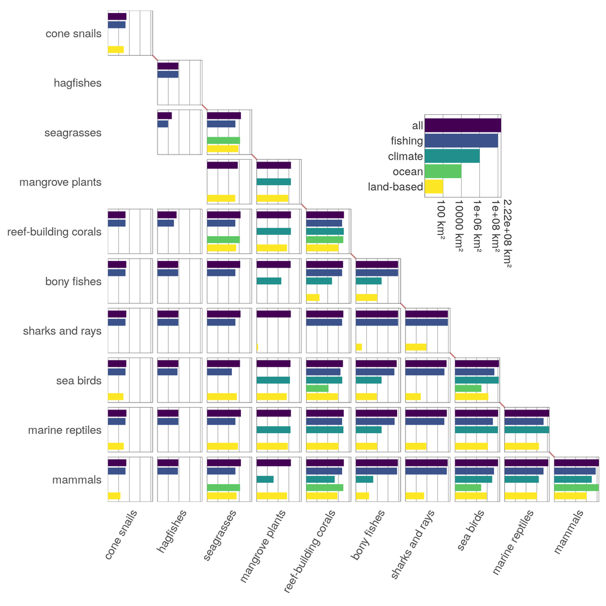

```r
lgd_ctr <- c(.75, .72)
lgd_size <- .2 ### This matches the mammal largest circle pretty well

fig <- ggdraw() +
  ### main plot
  draw_plot(fig_pairwise_plot + theme(legend.position = 'none')) +
  ### draw legend 1 figure
  draw_plot(get_panel(fig_legend),
            x = lgd_ctr[1] - .5 * lgd_size,
            y = lgd_ctr[2] - .5 * lgd_size,
            width = lgd_size, height = lgd_size)


fig_file <- here('ms_figs/figS7_taxa_cooccur_square.png')

ggsave(plot = fig, filename = fig_file,
       width = 6.5, height = 6.5, units = 'in', dpi = 300)

knitr::include_graphics(fig_file)
```